# Vulnerability of Ca<sup>++</sup> stocks of a reference Swedish forest in a climatic change scenario

## Future Ca vulnerability assuming constant input and climate

First of all we need to assume some future C inputs. For simplicity we assume a conservation scenario, and extend the inputs 50 years in the future by using a mean (of the whole time series):

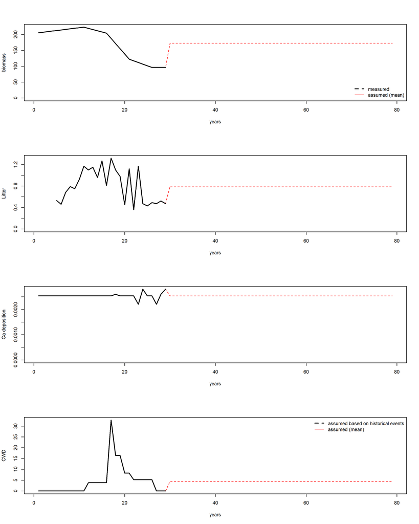

This produces the following predictions concerning the Ca<sup>++</sup> ions:

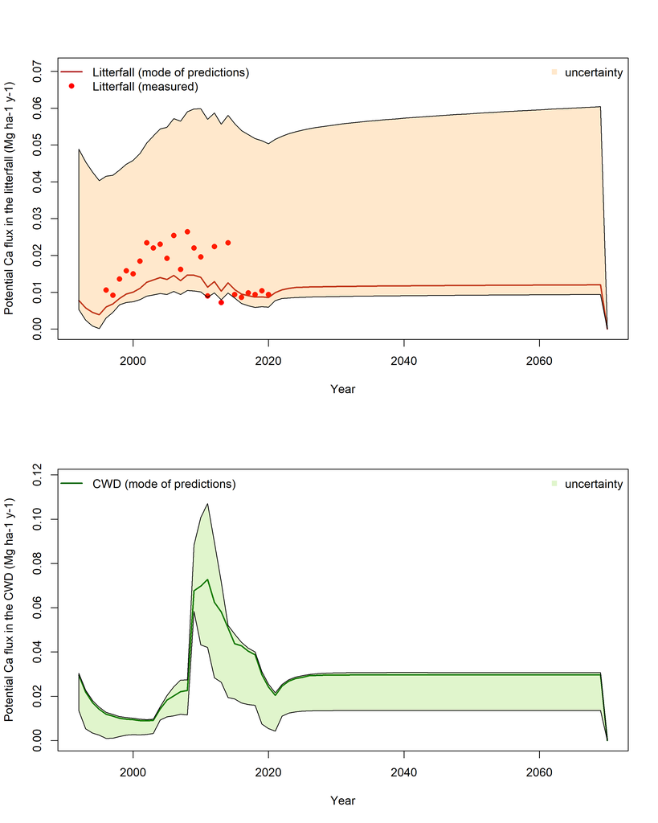

This picture is of course highly dependent on the inputs, in particular the CWD inputs.

When considering instead future climate, we can simulate the effect of the foreseen change in precipitation in the Ca content of the biomass:

## 2.2.1 Future Ca vulnerability assuming constant input and changing climate

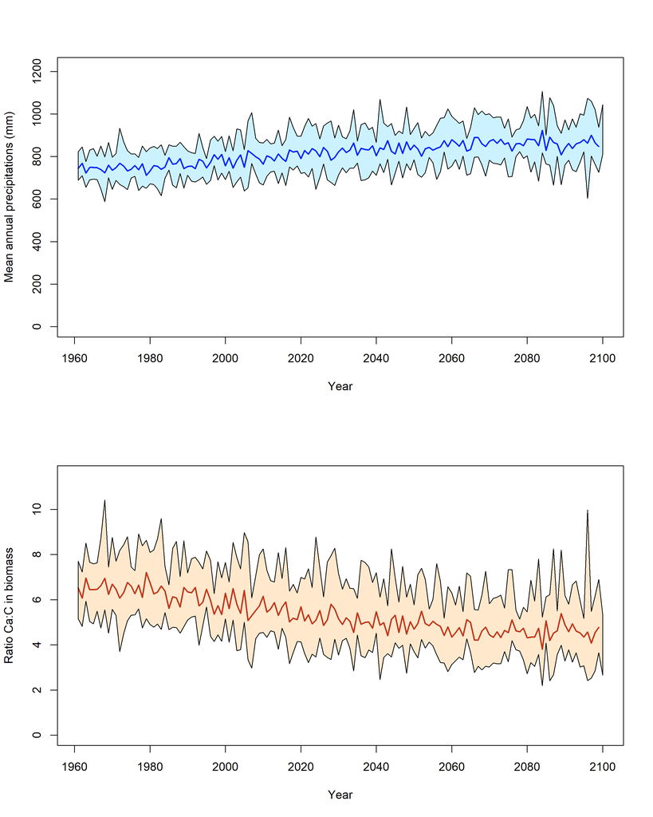

Predicted future precipitations in Aneboda, and the consequent Ca:C ratio in the biomass

We then use these data to drive a new decomposition simulation. We first transform min, max and mean Ca scenarios in a relative variation, and we apply this variation both to the living and dead Ca:C ratio.

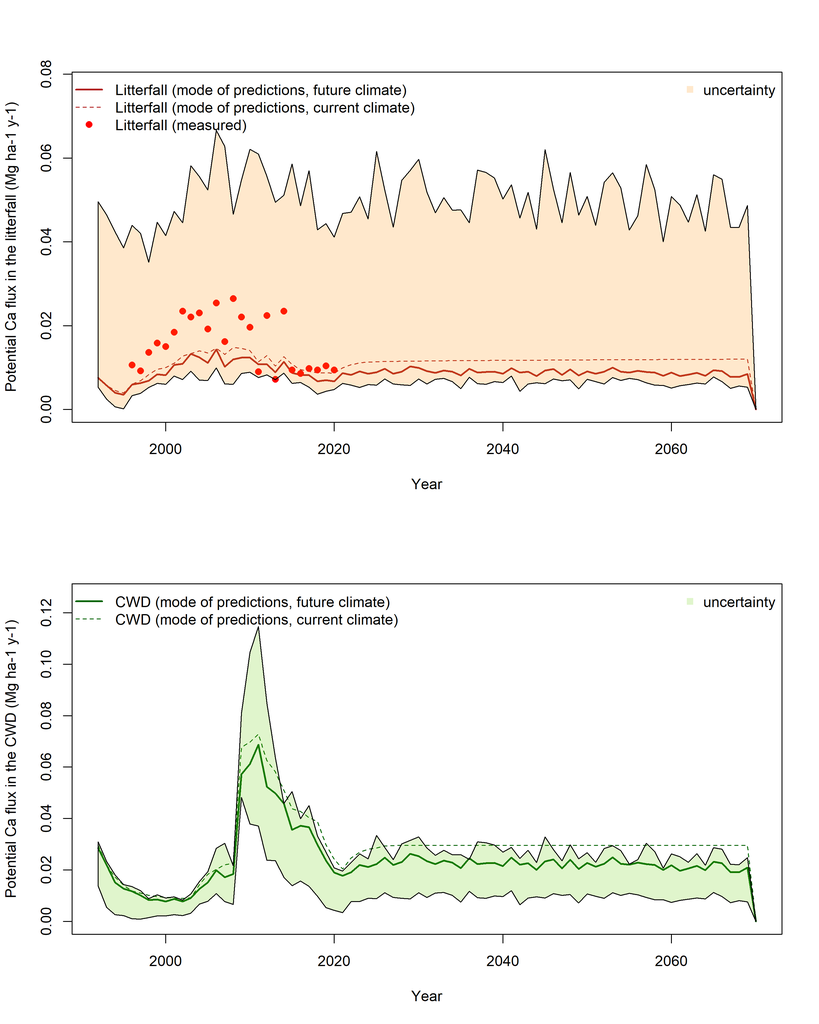

The simulation considering uncertainty and the future climate effect on Ca content, based on Q

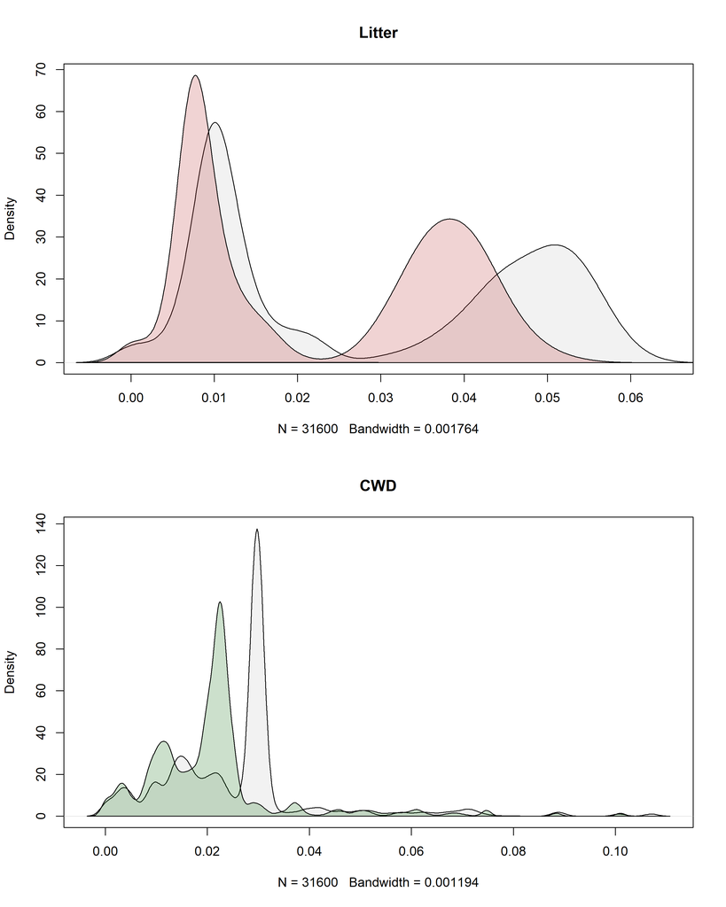

The bimodal probability distribution of the litter stocks is probably due to the model calibration used presenting a bimodal distribution for some parameters, which in turns represent different types of dead wood (the different peaks are probably representing different kind of materials with different kinetics, for example snags or logs and of different species. The resulting model ensemble is anyway more robust)

## Future Ca vulnerability in a simulated forest management assuming variable climate and a natural disasters

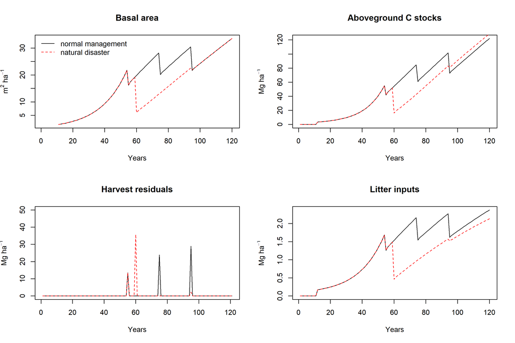

we assumed that only 50% of the dead trees was recovered, while the remaining was lost to decomposition. This produced a very clear peak in the amount of Ca mobilized caused by the tree death event:

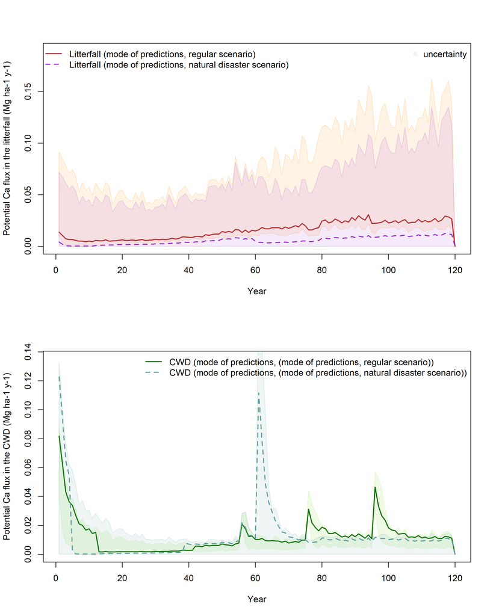

The two forest management scenarios